# NETFLIX Análisis

Jorge Guzmán

30/7/2022

En este documento haremos un breve análisis de una base de datos de Netflix. Las bases obtenidas fueron importadas del siguiente link: https://www.kaggle.com/datasets/victorsoeiro/netflix-tv-shows-and-movies

Después de haberlas descargado lo primero que haremos será importarlas.

```r
titles<-read.csv("titles.csv", encoding="UTF-8") #Usamos UTF-8 para los acentos
cast<-read.csv("credits.csv", encoding="UTF-8")
```

Para nuestro análisis utilizaremos la paquetería “tidyverse”, la llamamos:

```r
library(tidyverse)
```

Lo primero que haremos con nuestras bases será un pequeño análisis explotario, para ver su composición

```r
colnames(titles)
```

```
##  [1] "id"                   "title"                "type"
##  [4] "description"          "release_year"         "age_certification"
##  [7] "runtime"              "genres"               "production_countries"
## [10] "seasons"              "imdb_id"              "imdb_score"
## [13] "imdb_votes"           "tmdb_popularity"      "tmdb_score"
```

```r
str(titles)
```

```
## 'data.frame':    5806 obs. of  15 variables:
##  $ id                  : chr  "ts300399" "tm84618" "tm127384" "tm70993" ...
##  $ title               : chr  "Five Came Back: The Reference Films" "Taxi Driver" "Monty Python and the Holy Grail" "Life of Brian" ...
##  $ type                : chr  "SHOW" "MOVIE" "MOVIE" "MOVIE" ...
##  $ description         : chr  "This collection includes 12 World War II-era propaganda films — many of which are graphic and offensive — discu"| __truncated__ "A mentally unstable Vietnam War veteran works as a night-time taxi driver in New York City where the perceived "| __truncated__ "King Art…
##  $ release_year        : int  1945 1976 1975 1979 1973 1969 1971 1964 1980 1967 ...
##  $ age_certification   : chr  "TV-MA" "R" "PG" "R" ...
##  $ runtime             : int  48 113 91 94 133 30 102 170 104 110 ...
##  $ genres              : chr  "['documentation']" "['crime', 'drama']" "['comedy', 'fantasy']" "['comedy']" ...
##  $ production_countries: chr  "['US']" "['US']" "['GB']" "['GB']" ...
##  $ seasons             : num  1 NA NA NA NA 4 NA NA NA NA ...
##  $ imdb_id             : chr  "" "tt0075314" "tt0071853" "tt0079470" ...
##  $ imdb_score          : num  NA 8.3 8.2 8 8.1 8.8 7.7 7.8 5.8 7.7 ...
##  $ imdb_votes          : num  NA 795222 530877 392419 391942 ...
##  $ tmdb_popularity     : num  0.6 27.6 18.2 17.5 95.3 ...
##  $ tmdb_score          : num  NA 8.2 7.8 7.8 7.7 8.3 7.5 7.6 6.2 7.5 ...
```

```r
summary(titles)
```

```
##       id               title               type           description
##  Length:5806        Length:5806        Length:5806        Length:5806
##  Class :character   Class :character   Class :character   Class :character
##  Mode  :character   Mode  :character   Mode  :character   Mode  :character
##
##
##
##
##   release_year  age_certification     runtime          genres
##  Min.   :1945   Length:5806        Min.   :  0.00   Length:5806
##  1st Qu.:2015   Class :character   1st Qu.: 44.00   Class :character
##  Median :2018   Mode  :character   Median : 84.00   Mode  :character
##  Mean   :2016                      Mean   : 77.64
##  3rd Qu.:2020                      3rd Qu.:105.00
##  Max.   :2022                      Max.   :251.00
##
##  production_countries    seasons         imdb_id            imdb_score
##  Length:5806          Min.   : 1.000   Length:5806        Min.   :1.500
##  Class :character     1st Qu.: 1.000   Class :character   1st Qu.:5.800
##  Mode  :character     Median : 1.000   Mode  :character   Median :6.600
##                       Mean   : 2.166                      Mean   :6.533
##                       3rd Qu.: 2.000                      3rd Qu.:7.400
##                       Max.   :42.000                      Max.   :9.600
##                       NA's   :3759                        NA's   :523
##    imdb_votes      tmdb_popularity       tmdb_score
##  Min.   :      5   Min.   :   0.0094   Min.   : 0.500
##  1st Qu.:    521   1st Qu.:   3.1553   1st Qu.: 6.100
##  Median :   2279   Median :   7.4780   Median : 6.900
##  Mean   :  23407   Mean   :  22.5257   Mean   : 6.818
##  3rd Qu.:  10144   3rd Qu.:  17.7757   3rd Qu.: 7.500
##  Max.   :2268288   Max.   :1823.3740   Max.   :10.000
##  NA's   :539       NA's   :94          NA's   :318
```

```r
colnames(cast)
```

```
## [1] "person_id" "id"        "name"      "character" "role"
```

```r
str(cast)
```

```
## 'data.frame':    77213 obs. of  5 variables:
##  $ person_id: int  3748 14658 7064 3739 48933 32267 519612 29068 519613 3308 ...
##  $ id       : chr  "tm84618" "tm84618" "tm84618" "tm84618" ...
##  $ name     : chr  "Robert De Niro" "Jodie Foster" "Albert Brooks" "Harvey Keitel" ...
##  $ character: chr  "Travis Bickle" "Iris Steensma" "Tom" "Matthew 'Sport' Higgins" ...
##  $ role     : chr  "ACTOR" "ACTOR" "ACTOR" "ACTOR" ...
```

```r
summary(cast)
```

```
##    person_id            id                name            character
##  Min.   :      7   Length:77213       Length:77213       Length:77213
##  1st Qu.:  41584   Class :character   Class :character   Class :character
##  Median : 182985   Mode  :character   Mode  :character   Mode  :character
##  Mean   : 499460
##  3rd Qu.: 841557
##  Max.   :2371585
##      role
##  Length:77213
##  Class :character
##  Mode  :character
##
##
##
```

En este caso, ambas bases se encuentran limpias así que no será necesario realizar correcciones, procederemos a realizar una visualización y análisis de los datos.

# Visualización de datos

Lo primero que haremos será averiguar como se compone el catálogo respecto a la cantidad de películas y de series.

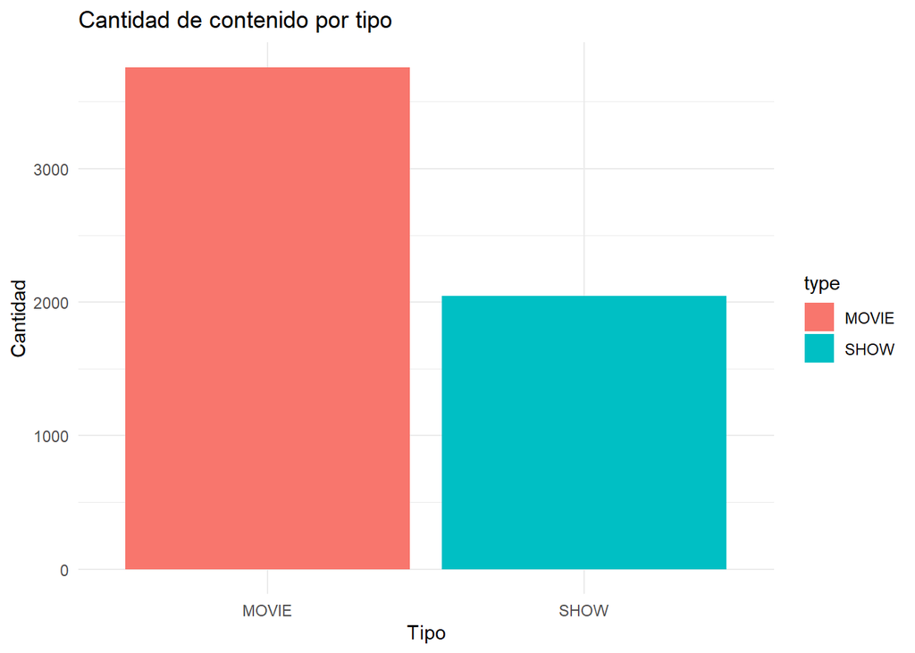

```r
ggplot(titles)+
  geom_bar(aes(x=type, fill=type))+
  labs(title="Cantidad de contenido por tipo", y="Cantidad", x="Tipo")+
  theme_minimal()
```

Como podemos observar, el catálogo de películas disponibles es casi del doble de lo correspondiente a shows.

```r
base1<-filter(titles, type=="MOVIE")
mean(base1$runtime)
```

```
## [1] 98.78532
```

```r
base2<-filter(titles, type=="SHOW")
mean(base2$runtime)
```

```
## [1] 38.8212
```

```r
mean(base2$seasons)
```

```
## [1] 2.165608
```

También notamos que el promedio de duración de las películas es de 98 minutos a diferencia de las series que es de 38 minutos. Además, las series tienen un promedio de 2.16 temporadas.

## Películas

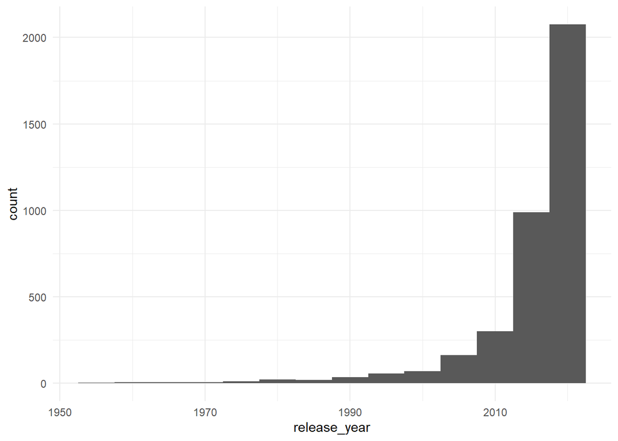

```r
titles %>% filter(type=="MOVIE") %>%
  ggplot()+
  geom_histogram(aes(x=release_year), binwidth = 5)+
  theme_minimal()
```

```r
movies<-filter(titles, type=="MOVIE")
titles2010 <- movies %>%
  filter(release_year>2010)
nrow(titles2010)/nrow(movies)
```

```
## [1] 0.8555467
```

```r
titles2015 <- movies %>%
  filter(release_year>2015)
nrow(titles2015)/nrow(movies)
```

```
## [1] 0.7185422
```

En el caso de las películas el 85% fueron estrenadas hace menos de 10 años y el 71% hace menos de 5 años.

```r
titles %>% filter(type=="MOVIE") %>%
  select(title, imdb_score, release_year) %>%
  arrange(-imdb_score) %>%
  head(10)
```

```
##                                       title imdb_score release_year
## 1                            No Longer Kids        9.0         1979
## 2      Chhota Bheem & Krishna in Mayanagari        9.0         2011
## 3                         C/o Kancharapalem        9.0         2018
## 4  David Attenborough: A Life on Our Planet        9.0         2020
## 5                              Forrest Gump        8.8         1994
## 6                                 Inception        8.8         2010
## 7                       Sky Tour: The Movie        8.8         2020
## 8                            Bye Bye London        8.7         1982
## 9                       A Lion in the House        8.7         2006
## 10                               Anbe Sivam        8.7         2003
```

```r
titles1 <- filter(titles, type=="MOVIE")
summary(titles1$imdb_score)
```

```
##    Min. 1st Qu.  Median    Mean 3rd Qu.    Max.    NA's
##   1.500   5.600   6.400   6.267   7.100   9.000     352
```

En la tabla anterior observamos cuales son las 10 películas con mayor calificación según IMDB, y también obtenemos que la calificación promedio para una película es de 6.26.

# Series

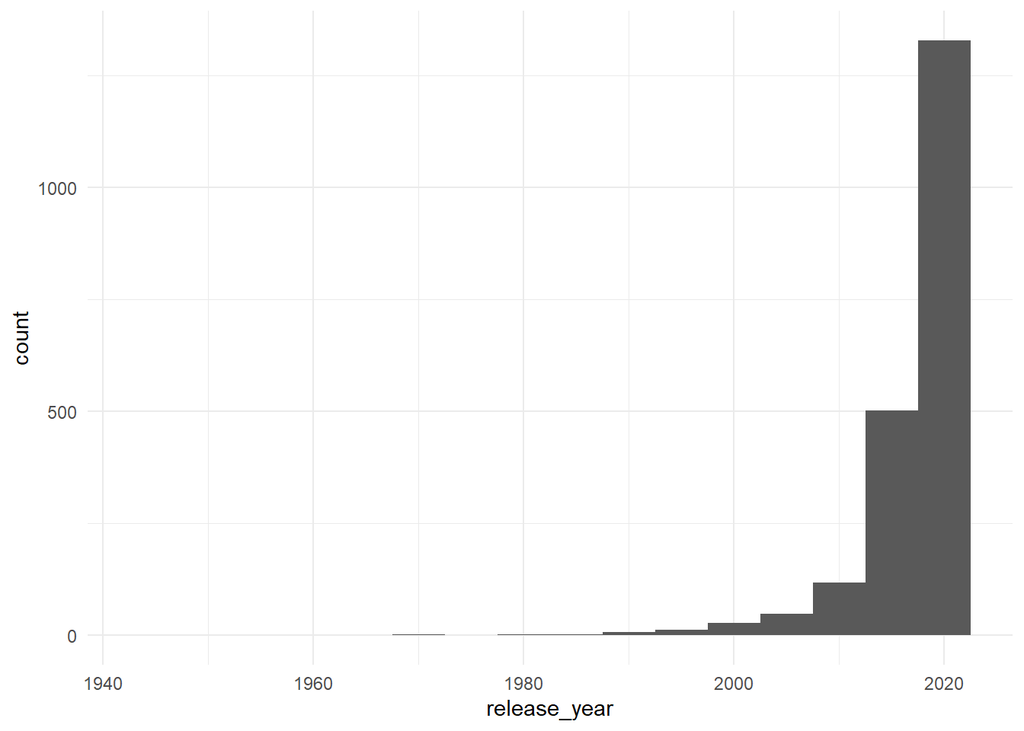

```r
titles %>% filter(type=="SHOW") %>%
  ggplot()+
  geom_histogram(aes(x=release_year), binwidth = 5)+
  theme_minimal()
```

```r
series<-filter(titles, type=="SHOW")
titles2010 <- series %>%
  filter(release_year>2010)
nrow(titles2010)/nrow(series)
```

```
## [1] 0.9233024
```

```r
titles2015 <- series %>%
  filter(release_year>2015)
nrow(titles2015)/nrow(series)
```

```
## [1] 0.8070347
```

En el caso de las series el 92% se estrenó hace menos de 10 años y el 80% hace menos de 5 años.

```r
series %>%
  select(title, seasons, release_year) %>%
  arrange(-seasons) %>%
  head(10)
```

```
##                       title seasons release_year
## 1                  Survivor      42         2000
## 2          Wheel of Fortune      39         1983
## 3             The Challenge      37         1998
## 4             Power Rangers      29         1993
## 5          Thomas & Friends      24         1984
## 6                   Pokémon      24         1997
## 7  America's Next Top Model      24         2003
## 8                 One Piece      21         1999
## 9                      NCIS      19         2003
## 10           Grey's Anatomy      18         2005
```

En la tabla anterior podemos observar las series con el mayor número de temporadas, ocupando el primer puesto Survivor con un total de 42 temporadas.

```r
series %>%
  select(title, imdb_score, release_year) %>%
  arrange(-imdb_score) %>%
  head(10)
```

```
##                         title imdb_score release_year
## 1                    Khawatir        9.6         2005
## 2                    #ABtalks        9.6         2018
## 3                Breaking Bad        9.5         2008
## 4  Avatar: The Last Airbender        9.3         2005
## 5                  Our Planet        9.3         2019
## 6                Kota Factory        9.3         2019
## 7                  Reply 1988        9.2         2015
## 8                   My Mister        9.2         2018
## 9         Who Rules The World        9.2         2022
## 10             The Last Dance        9.1         2020
```

En la tabla anterior tenemos el Top 10 de las series mejor calificadas. Podemos ver que dentro de los primeros lugares encontramos Breaking Bad y Avatar.

# Actores y Directores

Ahora estamos interesados en saber cuales son los actores y directores que han participado en más proyectos y también cuales han obtenido un mejor desempeño. Para lograr el objetivo anterior primero será necesario realizar un join entre las dos bases de datos, para ellos utilizaremos la columna id que se encuentra en ambas bases, primero filtraremos las columnas que requerimos por cada base:

#### titles

- id
- title
- imdb_score

#### cast

- id
- name
- role

```r
titles1<-titles %>%
  select(id, title, imdb_score)
head(titles1)
```

```
##         id                               title imdb_score
## 1 ts300399 Five Came Back: The Reference Films         NA
## 2  tm84618                         Taxi Driver        8.3
## 3 tm127384     Monty Python and the Holy Grail        8.2
## 4  tm70993                       Life of Brian        8.0
## 5 tm190788                        The Exorcist        8.1
## 6  ts22164        Monty Python's Flying Circus        8.8
```

```r
cast1<-cast %>%
  select(id, name, role)
head(cast1)
```

```
##        id            name  role
## 1 tm84618  Robert De Niro ACTOR
## 2 tm84618    Jodie Foster ACTOR
## 3 tm84618   Albert Brooks ACTOR
## 4 tm84618   Harvey Keitel ACTOR
## 5 tm84618 Cybill Shepherd ACTOR
## 6 tm84618     Peter Boyle ACTOR
```

Ahora procederemos a realizar el join:

```r
base1<-merge(x=cast1, y=titles1, by.x="id", by.y="id", all.x=TRUE)
head(base1)
```

```
##          id             name  role        title imdb_score
## 1 tm1000037      Luna Wedler ACTOR Je suis Karl        5.4
## 2 tm1000037 Jannis Niewöhner ACTOR Je suis Karl        5.4
## 3 tm1000037    Milan Peschel ACTOR Je suis Karl        5.4
## 4 tm1000037   Edin Hasanovic ACTOR Je suis Karl        5.4
## 5 tm1000037     Anna Fialová ACTOR Je suis Karl        5.4
## 6 tm1000037     Marlon Boess ACTOR Je suis Karl        5.4
```

## Directores

Primero veremos cuáles son los directores con más participaciones.

```r
directores<-filter(base1, role=="DIRECTOR")
directores %>% group_by(name) %>%
  summarise(n=n(), promedio=mean(imdb_score)) %>%
  arrange(-n) %>%
  head(10)
```

```
## # A tibble: 10 x 3
##    name                    n promedio
##    <chr>               <int>    <dbl>
##  1 Raúl Campos            21     6.16
##  2 Jan Suter              20     6.14
##  3 Jay Karas              16    NA
##  4 Marcus Raboy           15     6.55
##  5 Ryan Polito            13    NA
##  6 Cathy Garcia-Molina    12     7.02
##  7 Jay Chapman            12    NA
##  8 Youssef Chahine        11     6.99
##  9 Justin G. Dyck          9     4.96
## 10 Anurag Kashyap          8    NA
```

Como podemos observar el director con más participaciones es Raúl Campos con 21.

Ahora averiguaremos cual es el director con un mejor promedio de calificaciones en sus películas.

```r
directores %>% group_by(name) %>%
  summarise(promedio=mean(imdb_score)) %>%
  arrange(-promedio) %>%
  head(10)
```

```
## # A tibble: 10 x 2
##    name                promedio
##    <chr>                  <dbl>
##  1 Jason Hehir             9.1
##  2 Alastair Fothergill     9
##  3 Bruno Stagnaro          9
##  4 Hiroshi Koujina         9
##  5 Jonathan Hughes         9
##  6 Keith Scholey           9
##  7 Samir Al Asfory         9
##  8 Shin Won-ho             8.85
##  9 Ka-Lam Chan             8.8
## 10 Robert Zemeckis         8.8
```

En este caso tenemos a Jason Hehir liderando la lista. Pero ahora seremos un poco más exigentes y sólo meteremos al ranking a directores con más de 5 películas.

```r
directores %>% group_by(name) %>%
  summarise(n=n(), promedio=mean(imdb_score)) %>%
  filter(n>5) %>%
  arrange(-promedio) %>%
  head(10)
```

```
## # A tibble: 10 x 3
##    name                    n promedio
##    <chr>               <int>    <dbl>
##  1 Mani Ratnam             6     7.75
##  2 Shannon Hartman         7     7.24
##  3 Cathy Garcia-Molina    12     7.02
##  4 Youssef Chahine        11     6.99
##  5 Lance Bangs             7     6.7
##  6 Ashutosh Gowariker      6     6.58
##  7 Troy Miller             8     6.56
##  8 Marcus Raboy           15     6.55
##  9 Raúl Campos            21     6.16
## 10 Jan Suter              20     6.14
```

Dado este criterio el director con mayor calificación promedio en sus películas es Mani Ratnam.

## Actores

Primero veremos cuáles son los actores con más participaciones.

```r
actores<-filter(base1, role=="ACTOR")
actores %>% group_by(name) %>%
  summarise(n=n(), promedio=mean(imdb_score)) %>%
  arrange(-n) %>%
  head(10)
```

```
## # A tibble: 10 x 3
##    name                      n promedio
##    <chr>                 <int>    <dbl>
##  1 Shah Rukh Khan           30    NA
##  2 Anupam Kher              25     6.05
##  3 Boman Irani              25     6.47
##  4 Kareena Kapoor Khan      25     6.31
##  5 Paresh Rawal             22     6.41
##  6 Takahiro Sakurai         22    NA
##  7 Nawazuddin Siddiqui      21     7.17
##  8 Priyanka Chopra Jonas    21     6.43
##  9 Amitabh Bachchan         19     6.59
## 10 Fred Tatasciore          19    NA
```

El actor con más participaciones es Shah Rukh Khan de origen indio, con un total de 30 participaciones.

```r
actores<-filter(base1, role=="ACTOR")
actores %>% group_by(name) %>%
  summarise(promedio=mean(imdb_score)) %>%
  arrange(-promedio) %>%
  head(10)
```

```
## # A tibble: 10 x 2
##    name          promedio
##    <chr>            <dbl>
##  1 Anna Gunn          9.5
##  2 Betsy Brandt       9.5
##  3 Cricket Leigh      9.3
##  4 Jessie Flower      9.3
##  5 Zach Tyler         9.3
##  6 He Kailang         9.2
##  7 Kim Seol           9.2
##  8 Lee Hye-ri         9.2
##  9 Lee Ji-ah          9.2
## 10 Ryu Jun-yeol       9.2
```

Las actrices cuyas películas realizadas cuentan con un mejor promedio de calificación son Anna Gunn y Betsy Brandt, ambas americanas con papeles importantes en Breaking Bad.

Ahora veremos que pasa con la lista anterior al considerar actores que hayan realizado más de 5 películas.

```r
actores %>% group_by(name) %>%
  summarise(n=n(), promedio=mean(imdb_score)) %>%
  filter(n>5) %>%
  arrange(-promedio) %>%
  head(10)
```

```
## # A tibble: 10 x 3
##    name                 n promedio
##    <chr>            <int>    <dbl>
##  1 You Chea-myung       6     7.93
##  2 Carol Cleveland      6     7.9
##  3 Park Ho-san          6     7.88
##  4 Kisho Taniyama       6     7.87
##  5 Haruka Tomatsu      10     7.81
##  6 Lee Jung-eun         9     7.79
##  7 Yuriko Yamaguchi     7     7.79
##  8 Lee Joon-hyuk        6     7.77
##  9 Eri Kitamura         6     7.73
## 10 Aamir Khan          18     7.71
```

Ahora el actor que se lleva el título es You Chea-Myung de origen surcoreano.